# 可视化 ggplot2入门

xizhihui

2018/11/02

久闻 ggplot2 大名，它的出图也在各个生信分析包中随处可见。今天恰好买来的新书《R 数据科学》里面有讲解，遂随着它一起学习一下，也将以前的相关学习一齐记录于此。

这里我们使用的是 ggplot2 自带的 mpg 和 diamonds 数据集，还有 nlme 的Oxboys 数据集。

```r
suppressMessages(library(ggplot2))
suppressMessages(library(reshape2))

mpg[1:5, ]
```

```
## # A tibble: 5 x 11
##   manufacturer model displ  year   cyl trans drv     cty   hwy fl    class
##   <chr>        <chr> <dbl> <int> <int> <chr> <chr> <int> <int> <chr> <chr>
## 1 audi         a4      1.8  1999     4 auto~ f        18    29 p     comp~
## 2 audi         a4      1.8  1999     4 manu~ f        21    29 p     comp~
## 3 audi         a4      2    2008     4 manu~ f        20    31 p     comp~
## 4 audi         a4      2    2008     4 auto~ f        21    30 p     comp~
## 5 audi         a4      2.8  1999     6 auto~ f        16    26 p     comp~
```

```r
diamonds[1:5, ]
```

```
## # A tibble: 5 x 10
##   carat cut     color clarity depth table price     x     y     z
##   <dbl> <ord>   <ord> <ord>   <dbl> <dbl> <int> <dbl> <dbl> <dbl>
## 1 0.23  Ideal   E     SI2      61.5    55   326  3.95  3.98  2.43
## 2 0.21  Premium E     SI1      59.8    61   326  3.89  3.84  2.31
## 3 0.23  Good    E     VS1      56.9    65   327  4.05  4.07  2.31
## 4 0.290 Premium I     VS2      62.4    58   334  4.2   4.23  2.63
## 5 0.31  Good    J     SI2      63.3    58   335  4.34  4.35  2.75
```

```r
data(Oxboys, package = "nlme")
Oxboys[1:5, ]
```

```
## # A tibble: 5 x 4
##   Subject     age height Occasion
## * <ord>     <dbl>  <dbl> <ord>
## 1 1       -1        140. 1
## 2 1       -0.748    143. 2
## 3 1       -0.463    145. 3
## 4 1       -0.164    147. 4
## 5 1       -0.0027   148. 5
```

## ggplot2 初探

### 用 ggplot2 画个图

```r
# step 1 生成 ggplot 画板，指定数据对象
myplot = ggplot(data=mpg)

# step 2 添加几何对象 (geom_point)，添加图形映射 (aes)
ggplot(data=mpg) +
    geom_point(mapping=aes(x=displ, y=hwy))

# step 3 添加其他图形映射, 如 color, size, alpha, shape
# 颜色属性 color 以 mpg$class 进行映射
# 大小属性 size 以 mpg$class 进行映射
ggplot(data=mpg) +
    geom_point(mapping = aes(x=displ, y=hwy, color=class, size=class))

# step 4 尝试改变几何对象的图形属性, 注意与图形映射属性的差别
ggplot(data=mpg) +
    geom_point(mapping = aes(x=displ, y=hwy), color="blue")

# step 5 尝试使用连续变量来映射图形属性,
# 这时候分类变量就会变成连续的图形属性，比如 color 是颜色过渡而非颜色分类;
# 对于本就是连续变量的图形属性来讲，就没啥影响，比如 size
# 这里的 dispal < 5 生成了一个分类变量
ggplot(data = mpg) +
    geom_point(mapping = aes(x=displ, y=hwy, size=cty, color=displ < 5))

# step 6 分面的引入
# 前面通过添加图形属性映射来添加新的变量；
# 除此之外，也可以通过分面实现，但是要注意，二者的表现形式不同
# 分面会对变量进行 level，根据 level 设置对应的分面；即便使用的是连续变量
# 单变量分面, 我们得到的是网格形式排列（行列）的分面，ncol 和 nrow 指定行列数
ggplot(data=mpg) +
    geom_point(mapping=aes(x=displ, y=hwy)) +
    facet_wrap(~ class)
# 双变量分面
ggplot(data=mpg) +
    geom_point(mapping = aes(x=displ, y=hwy)) +
    facet_grid(drv ~ cyl)
ggplot(data=mpg) +
    geom_point(mapping = aes(x=displ, y=hwy)) +
    facet_grid(cyl ~ drv)
# 单变量分面，不做网格形式，仅做行排列或列排列
ggplot(data=mpg) +
    geom_point(mapping = aes(x=displ, y=hwy)) +
    facet_grid(class ~ .)
ggplot(data=mpg) +
    geom_point(mapping = aes(x=displ, y=hwy)) +
    facet_grid(. ~ class)

# step 7 使用其他几何对象来表现数据
ggplot(data=mpg) +
    geom_point(mapping=aes(x=displ, y=hwy, color=class)) +
    geom_smooth(mapping=aes(x=displ, y=hwy, linetype=class, color=class))

# step 8 不同的几何对象的公有和私有图形属性映射
ggplot(data=mpg, mapping=aes(x=displ, y=hwy)) +
    geom_point(mapping=aes(color=class)) +
    geom_smooth()
# step 9 不同几何对象的私有数据对象, geom_smooth 只对 subcompact 生成拟合曲线
ggplot(data=mpg, mapping=aes(x=displ, y=hwy)) +
    geom_point(mapping=aes(color=class)) +
    geom_smooth(data=filter(mpg, class=="subcompact"), se=F)
```

### 尝试一个数据的不同画法

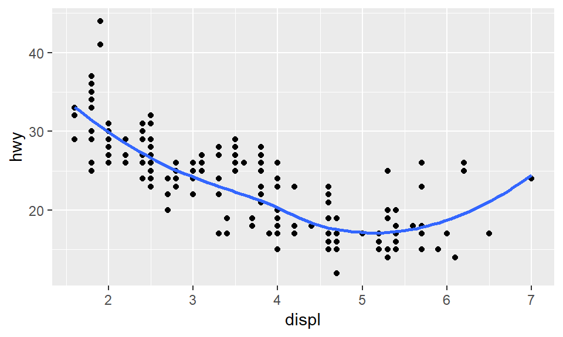

```r
# step 10 尝试一个数据的不同画法
ggplot(data=mpg, mapping=aes(x=displ, y=hwy)) +
    geom_point() +
    geom_smooth(se=F)
```

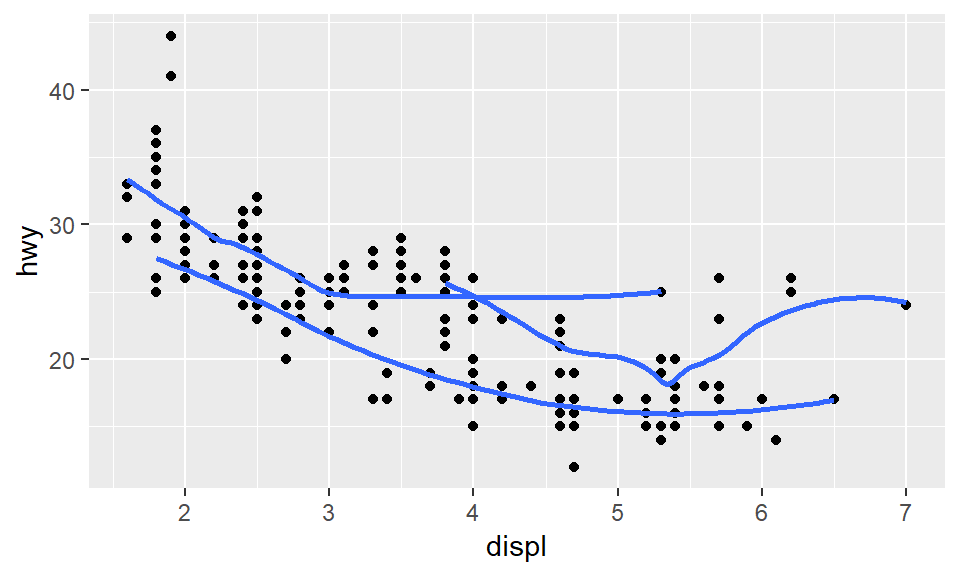

```r
ggplot(data=mpg, mapping=aes(x=displ, y=hwy)) +
    geom_point() +
    geom_smooth(se=F, mapping=aes(group=drv))
```

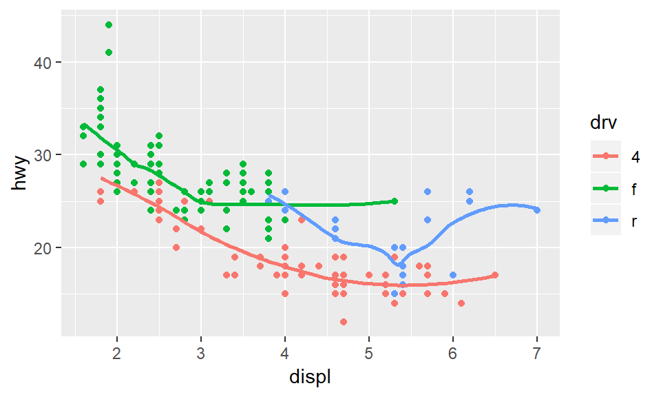

```r
ggplot(data=mpg, mapping=aes(x=displ, y=hwy, color=drv)) +
    geom_point() +
    geom_smooth(se=F)
```

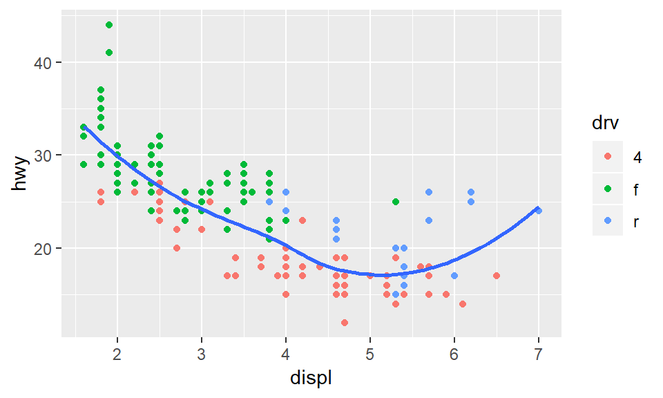

```r
ggplot(data=mpg, mapping=aes(x=displ, y=hwy)) +
    geom_point(mapping=aes(color=drv)) +
    geom_smooth(se=F)
```

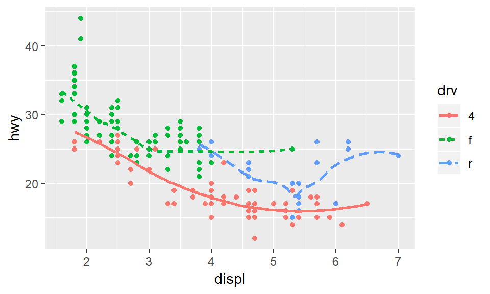

```r
ggplot(data=mpg, mapping=aes(x=displ, y=hwy, color=drv)) +
    geom_point() +
    geom_smooth(se=F, mapping=aes(linetype=drv))
```

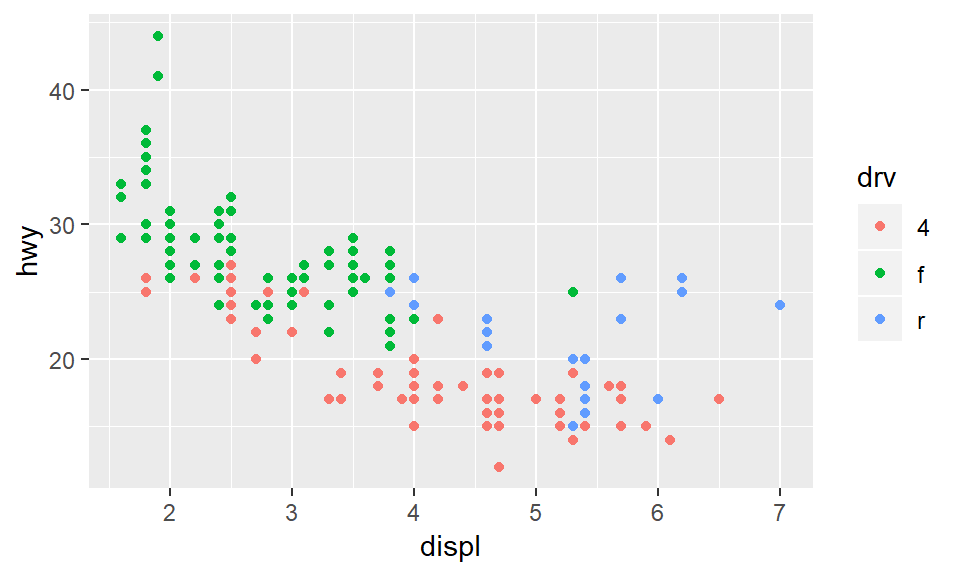

```r
ggplot(data=mpg, mapping=aes(x=displ, y=hwy, color=drv)) +
    geom_point()
```

### 引入其他新元素如统计变换、坐标变换

```r
# step 10 引入统计变换
ggplot(data=diamonds) +
    stat_summary(mapping=aes(x=cut, y=depth), fun.ymin=min, fun.ymax=max, fun.y=median)
ggplot(data=diamonds, mapping=aes(x=cut, y=depth)) + geom_boxplot()

ggplot(data=diamonds) +
    geom_bar(mapping=aes(x=cut, y=..prop.., group=1))
ggplot(data=diamonds) +
    geom_bar(mapping=aes(x=cut, y=..prop..))

ggplot(data=mpg, mapping=aes(x=cty, y=hwy)) + geom_point(position = "jitter")

## step 11 引入坐标变换
mybar = ggplot(data=diamonds, aes(x=cut, fill=clarity)) +
    geom_bar()
mybar + coord_flip()
mybar + coord_polar()

ggplot(data=mpg, mapping=aes(x=cty, y=hwy)) +
    geom_point() + geom_abline()
ggplot(data=mpg, mapping=aes(x=cty, y=hwy)) +
    geom_point() + geom_abline() + coord_fixed()
```

## ggplot2 进阶

> 在for循环和函数里, ggplot的图形需要显示调用print(plot)才能画出来.

### ggplot2 图形分层语法总结

```r
ggplot(data=<DATA>) +
    <geom_function>(
        mapping = aes(<MAPPINGS>),
        stat = <STAT>,
        position = <POSITION>
    ) +
    <scale_function> +
    <coord_function> +
    <facet_function>
```

- <DATA>, 数据：必须是一个数据框
- <MAPPINGS>, 一组图形属性映射，设定数据集中的变量如何映射到该图层的图形属性
- <geom_function>, 几何对象，指定在图层中进行绘图的几何对象类型
- <STAT>, 统计变换，指定时候对元数据进行统计变换
- <POSITION>, 位置调整，指定图形元素的位置，避免图形重合
- <coord_function>, 坐标变换: coordinate system, 描述数据与图形所在平面的映射关系
- <facet_function>, 分面设定: 条件作图或网格作图，分解数据成为子集并对后者作图、联合展示
- <scale_function>, 标度调整指定数据-图形属性、数据-位置、数据-坐标等的映射关系( f(x) )

### 数据和图形属性映射

#### 数据与映射

ggplot函数对数据的类型要求为数据框(data.frame),它不会直接修改原数据，而是创建一个副本。你可以使用 “%+%” 来改变数据集。你要保证aes的变量(这里是carat,price,cut)都是来自于data(这里是diamonds)，以保证ggplot对象是自含型的。在定义映射时，我们要注意区分设定和映射。例如下方darkblue，在定义为映射时，“darkblue”作为只有一个元素的变量，然后对该变量进行映射，所以你会发现画出的图形上会出现分组信息（单个组darkblue）而图形颜色不是darkblue。而设定则是直接把图形颜色设定为darkblue。这在前面 gglot2 初探的 step4 有涉及。

```r
p = ggplot(data=diamonds, aes(carat, price, colour=cut))
p %+% mtcars        # 进行映射的数据集被改为mtcars

p + geom_point(aes(colour='darkblue'))  # 映射
p + geom_point(colour='darkblue') # 设定
```

#### 分组、群组

有时候，我们想对数据进行分组展示。就需要对映射指定分组变量。分组变量的指定与否会产生很明显的差别（群组）。

```r
ggplot(Oxboys, aes(age, height, group=Subject)) + geom_line()
ggplot(Oxboys, aes(age, height, group=1)) + geom_line()
```

### 几何对象

geom，几何对象执行着图层的实际渲染，控制着生成的图像类型。每个几何对象都有一个默认的统计变换，且每个统计变换都有一个默认的几何对象。

| 几何对象 | 描述 | 默认统计变换 | 图形属性 |
| --- | --- | --- | --- |
| abline | 线,由斜率和截距决定 | abline | colour,linetype,size |
| area | 面积图 | identity | colour,fill,linetype,size,x,y |
| bar | 条形图, 以x轴为底的矩形 | bin | colour,fill,linetype,size,weight,x |
| bin2d | 2维热图 | bin2d | colour,fill,linetype,size,weight,xmax,xmin,ymax,ymin |
| blank | 空白,什么也不画 | identity |  |
| boxplot | 箱线图 | boxplot | colour,fill,lower,middle,size,upper,weight,x,ymax,ymin |
| contour | 等高线图 | contour | colour,linetype,size,weight,x,y |
| crossbar | 带有水平中心线的盒子图 | identity | colour,fill,linetype,size,x,y,ymax,ymin |
| density | 光滑密度曲线图 | density | colour,fill,linetype,size,weight,x,y |
| density2d | 二维密度等高线图 | density2d | colour,linetype,size,weight,x,y |
| dotplot | 点直方图,用点表示观测值的个数 | bindot | colour, fill, x, y |
| errorbar | 误差棒 | identity | colour,linetype,size,width,x,ymax,ymin |
| errorbarh | 水平的误差行 | identity | colour,linetype,size,width,x,ymax,ymin |
| freqpoly | 频率多边形图 | bin | colour,linetype,size |
| hex | 用六边形表示的二维热图 | binhex | colour,fill,size,x,y |
| histogram | 直方图 | bin | colour,fill,linetype,size,weight,x |
| hline | 水平线 | hline | colour,linetype,size |
| jitter | 给点添加扰动，减轻图形重叠问题 | identity | colour,fill,shape,size,x,y |
| line | 按照x坐标的大小顺序依次连接各个观测值 | identity | colour,linetype,size,x,y |
| linerange | 一条代表一个区间的竖直线 | identity | colour,linetype,size,x,ymax,ymin |
| map | 基准地图里的多边形 | identity | colour,fill,linetype,size,x,y,map_id |
| path | 按数据的原始顺序连接各个观测值 | identity | colour,linetype,size,x,y |
| point | 点,用来绘制散点图 | identity | colour,shape,fill,size,x,y |
| pointrange | 用一条中间带点的竖直线代表一个区间 | identity | colour,fill,linetype,shape,size,x,y,ymax,ymin |
| polygon | 多边形,相当于一个有填充的路径 | identity | colour,fill,linetype,size,x,y |
| quantile | 添加分位数回归线 | quantile | colour,linetype,size,weight,x,y |
| raster | 高效的矩形瓦片图 | identity | colour,fill,linetype,size,x,y |
| rect | 2维的矩形图 | identity | colour,fill,linetype,size,xmax,xmin,ymax,ymin |
| ribbon | 色带图,连续的x值所对应的y的范围 | identity | colour,fill,linetype,size,x,ymax,ymin |
| rug | 边际地毯图 | identity | colour,linetype,size |
| segment | 添加线段或箭头 | identity | colour,linetype,size,x,xend,y,yend |
| smooth | 添加光滑的条件均值线 | smooth | alpha,colour,fill,linetype,size,weight,x,y |
| step | 以阶梯形式连接各个观测值 | identity | colour,linetype,size,x,y |
| text | 文本注释 | identity | angle,colour, hjust,label,size, vjust,x,y |
| tile | 瓦片图 | identity | colour,fill,linetype,size,x,y |
| violin | 小提琴图 | yidentity | weight,colour,fill,size,linetype,x,y |
| vline | 竖直线 | vline | colour,linetype,size |

### 统计变换

stat，对数据进行统计变换，通常是对数据信息进行汇总。一个统计变换必须是一个位置尺度不变量，f(x+a)=f(x)+a && f(b*x)=b*f(x).统计变量通常会向原数据集中插入新的变量,你可以使用..xxx..的方式直接调用这些变量.

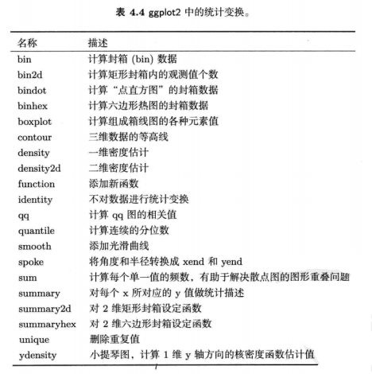

stats in ggplot

```r
ggplot(diamonds, aes(carat)) + geom_histogram(aes(y=..density..), binwidth=0.1)
```

### 位置调整

| 位置调整参数 | 描述 |
| --- | --- |
| dodge | 避免重叠，并排放置 |
| fill | 堆叠图形元素并将高度标准化为1 |
| identity | 不做任何调整 |
| jitter | 添加扰动避免重合 |
| stack | 把图形元素堆叠起来 |

### 标度

标度（scale）控制着数据到图形属性的映射，每一种标度都是从数据空间的某个区域（标度定义域）到图形属性空间的某个区域（标度值域）的一个函数.标度的执行过程分为3步，变换、训练和映射。变换是对数据进行汇总（统计变换），训练基于变换后的数据得到标度的定义域，最后映射到图形上去。使用时通过scale_aesType_scaleType来实现改变标度.

```
p = qplot(sleep_total, sleep_cycle, data=msleep, colour=vore)
p + scale_colour_hue('what does it eat?',
                    breaks=c('herbi', 'carni', 'omni', NA),
                    labels=c('plants', 'meants', 'both', 'dont know'))
p + scale_colour_brewer(palette='Set1')
```

#### 标度分类

标度可以粗略分为4类：位置标度、颜色标度、手动离散型标度和同一型标度。

- 位置标度：连续型、离散型、日期-时间型变量的映射到绘图区域，构造坐标轴
- 颜色标度：连续型、离散型变量映射到颜色
- 手动标度：离散型变量映射到我们选择的符号大小、线条类型、形状或颜色，创建对应图例
- 同一型标度：直接用变量值进行绘制图形属性，不执行映射。如颜色变量值

```r
# name: 使用xlab(name),ylab(name),labs()这三个辅助函数进行设置
p + xlab('City mpg')
p + labs(x='City mpg', y='Highway', colour='Displacement')

# limits: 固定标度的定义域, 可以移除不想在图形上展示的数据/保持不同范围数据的范围一致
# breaks&labels: 控制坐标轴显示的断点和在该断点上的标签，二者相匹配
p + scale_x_continuous(breaks=c(5.5, 6.5))      # 坐标轴在5.5、6.5处进行断点
p + scale_x_continuous(limits=c(5.5, 6.5))      # 整个图x轴的范围是5.5-6.5

# formatter：未指定标签时，在断点处调用formatter来生成格式化的标签。可用的标签刷为：
# 对于连续型：comma, percent, dollar, scientific
# 对于离散型标度：abbreviate
```

#### 位置标度

```r
p + scale_x_log10() + scale_y_log10()
p + scale_x_date(
    limits=as.Date(c('2004-01-01', '2005-01-01')),
    labels=date_format('%Y-%m-%d')
)
```

#### 颜色标度

```r
# 连续型
p + scale_fill_gradient(limits=c(0,0.04))
p + scale_fill_gradient(limits=c(0,0.04), low='white', high='black')    # 双色标度
p + scale_fill_gradient2(limits=c(-0.04,0.04), midpoint=0.02)           # 三色标度, gradientn是多色标度

# 离散型
p + scale_fill_brewer(palette='Set2')
p + scale_colour_brewer(palette='Pastel1')
```

#### 手动离散标度

```r
# 离散型标度
p + scale_linetype()
p + scale_size_discrete()
p + scale_shape()

# 如果定制这些离散型标度,则手动创建
p + scale_colour_manual(values=c('red','orange', 'yellow', 'green', 'blue'))
p + scale_shape_manual(values=c(1,2,6,0,23))
# 实际应用
ggplot(huron, aes(year)) +
    geom_line(aes(y=level-5, colour='below')) +
    geom_line(aes(y=level+5, colour='above')) +
    scale_colour_manual('Direction', values=c('below'='blue', 'above'='red'))
```

#### 同一型标度

当你的数据能被R中的绘图函数理解（数据空间和图形属性空间相同时），可以使用同一型标度。

## 常见图表代码

```r
attach(msleep)
mdata = msleep
festival.data = read.table('DownloadFestival.dat', sep='\t', header=T)
head(mdata)
```

```
## # A tibble: 6 x 11
##   name  genus vore  order conservation sleep_total sleep_rem sleep_cycle
##   <chr> <chr> <chr> <chr> <chr>              <dbl>     <dbl>       <dbl>
## 1 Chee~ Acin~ carni Carn~ lc                  12.1      NA        NA
## 2 Owl ~ Aotus omni  Prim~ <NA>                17         1.8      NA
## 3 Moun~ Aplo~ herbi Rode~ nt                  14.4       2.4      NA
## 4 Grea~ Blar~ omni  Sori~ lc                  14.9       2.3       0.133
## 5 Cow   Bos   herbi Arti~ domesticated         4         0.7       0.667
## 6 Thre~ Brad~ herbi Pilo~ <NA>                14.4       2.2       0.767
## # ... with 3 more variables: awake <dbl>, brainwt <dbl>, bodywt <dbl>
```

```r
head(festival.data)
```

```
## # A tibble: 6 x 5
##   ticknumb gender  day1  day2   day3
## *    <int> <fct>  <dbl> <dbl>  <dbl>
## 1     2111 Male    2.64  1.35  1.61
## 2     2229 Female  0.97  1.41  0.290
## 3     2338 Male    0.84 NA    NA
## 4     2384 Female  3.03 NA    NA
## 5     2401 Female  0.88  0.08 NA
## 6     2405 Male    0.85 NA    NA
```

### 常见几何对象及参数

- geom_bar(x,color,size,fill,linetype,alpha): 创建代表不同统计性质的条形图图层
- geom_point(x,y,shape,color,size,fill,alpha): 创建数据点图层
- geom_line(x,y,color,size,linetype,alpha): 创建直线图层
- geom_smooth(x,y,color,size,linetype,alpha): 创建平滑曲线图层(类似于回归曲线/点连线,但是更为平滑的曲线)
- geom_histogram(x,color,size,fill,linetype,alpha): 创建柱状图图层
- geom_boxplot(x,color,siz,fill,alpha): 创建box-whisker图图层
- geom_text(x,y,color,size,angle,hjust,vjust,alpha): 创建文本图层
- geom_errorbar(x,ymin,ymax,color,linetype,width,alpha): 创建误差线图层
- geom_hline(yintercept)/vline(xintercept,color,size,linetype,alpha): 创建水平线或垂直线图层

### 点图

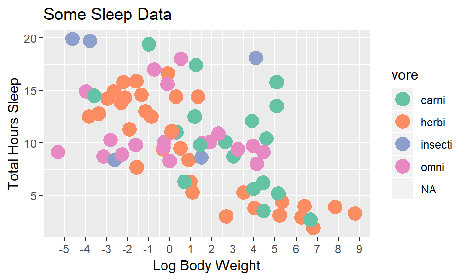

```r
{
    scatterplot = ggplot(data = mdata, aes(x=bodywt, y=sleep_total)) + geom_point()
    scatterplot
    # 添加颜色
    scatterplot = ggplot(data = mdata, aes(x=bodywt, y=sleep_total, col=vore)) + geom_point()
    scatterplot
    # 数据变换
    scatterplot = ggplot(data = mdata, aes(x=log(bodywt), y=sleep_total, col=vore)) + geom_point()
    scatterplot
    # 改变各种外观
    scatterplot = scatterplot + geom_point(size=5) +
                                xlab('Log Body Weight') +
                                ylab('Total Hours Sleep') +
                                ggtitle('Some Sleep Data')
    # 修改x轴刻度线，title位置
    scatterplot = scatterplot + scale_color_brewer(palette = 'Set2')
    scatterplot = scatterplot + theme(plot.title=element_text(vjust=+2))+scale_x_continuous(breaks=-5:10)
    # 调整背景颜色
    scatterplot = scatterplot + theme_set(theme_bw(base_size=18))
    scatterplot
}
```

### 带状点图

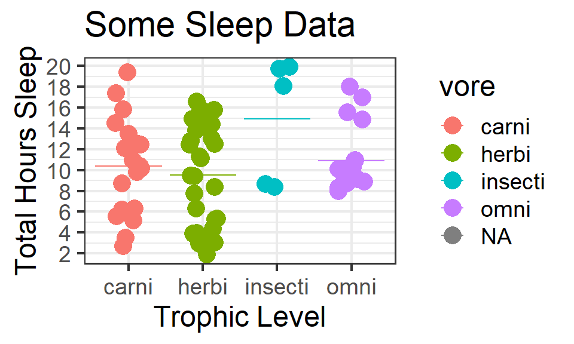

```r
{
    my.stripchart = ggplot(data=mdata, aes(vore, sleep_total)) + geom_point()
    # 改变大小，位置(左右偏移一些)
    my.stripchart = ggplot(data=mdata, aes(vore, sleep_total)) + geom_point(size=5, position='jitter')
    # 通过引入jitter图层来改变位置,默认用于point，所以不用在geom_point中指定
    my.stripchart = ggplot(data=mdata, aes(vore, sleep_total, col=vore)) +
                    geom_jitter(position=position_jitter(width = 0.2), size=5)
    # 添加误差线
    my.stripchart = my.stripchart +
                    ylab('Total Hours Sleep') + xlab('Trophic Level') +
                    stat_summary(fun.data = mdata, geom = "errorbar", width = .5) +
                    stat_summary(geom = "errorbar", fun.y = mean, aes(ymin = ..y.., ymax = ..y..))
    # 添加标题，去掉NA，调整y轴
    my.stripchart = my.stripchart +
                    scale_x_discrete(limits=c('carni', 'herbi', 'insecti', 'omni')) +
                    ggtitle('Some Sleep Data') +
                    theme(plot.title=element_text(vjust = +2)) +
                    scale_y_continuous(breaks=seq(0,20,2))
    my.stripchart
}
```

### 柱状图

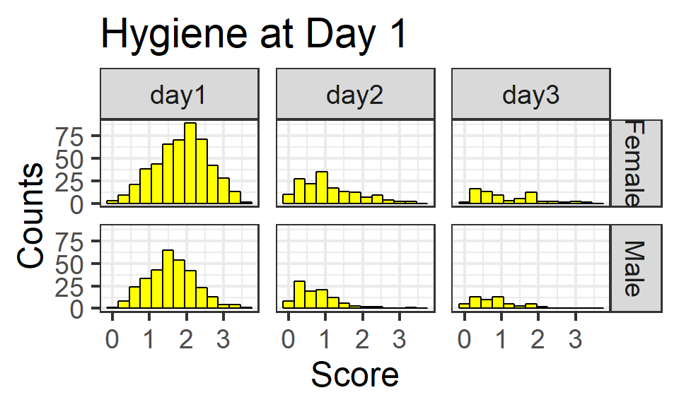

```r
{
    my.hist = ggplot(data=festival.data, aes(x=day1)) + geom_histogram()
    # 上点颜色咯
    my.hist = ggplot(data=festival.data, aes(x=day1)) +
                geom_histogram(binwidth=0.3, color='black', fill='yellow') +
                labs(x='Score', y='Counts') + ggtitle('Hygiene at Day 1')
    my.hist

    # 构造一下数据
    festival.data.stack = melt(festival.data, id=c('ticknumb', 'gender'))
    colnames(festival.data.stack)[3:4]<-c('day','score')
    head(festival.data.stack)

    # 运用facet进行分组,有两种方式 facet_grid(), facet_wrap()
    my.hist.day3 = ggplot(data=festival.data.stack,aes(score)) +
                geom_histogram(binwidth=0.3, color='black', fill='yellow') +
                labs(x='Score', y='Counts') + ggtitle('Hygiene at Day 1') +
                facet_grid(gender~day)
    my.hist.day3
}
```

### 画个stripchart;

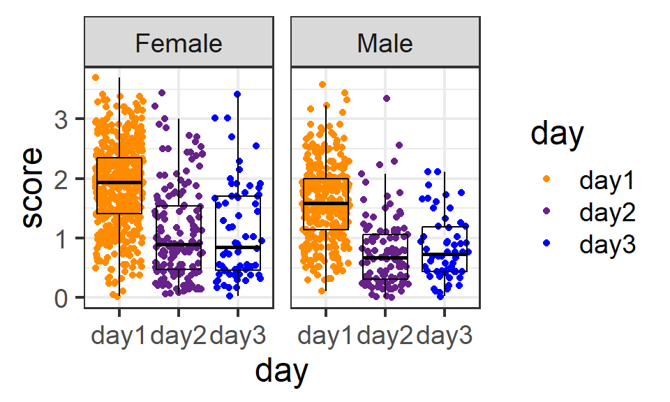

```r
{
    # color用于分亚组，gender用于分大组；所以color分组的话与x是一致的分组
    # facet_gripd用于分大组
    my.stripchart.day3 = ggplot(data=na.omit(festival.data.stack), aes(day,score, color=day)) +
                geom_point(position='jitter') + facet_grid(~gender)
    my.stripchart.day3 = my.stripchart.day3 +
                stat_summary(fun.data = na.omit(festival.data.stack), geom = "errorbar", width = .5) +
                stat_summary(geom = "errorbar", fun.y = mean, aes(ymin = ..y.., ymax = ..y..))
# 带箱图的stripchart
    my.stripchart.day3 = ggplot(data=na.omit(festival.data.stack), aes(day,score, color=day)) +
                geom_point(position='jitter') + facet_grid(~gender) +
                scale_colour_manual(values=c("darkorange", "darkorchid4",'blue')) +
                geom_boxplot(alpha=0, colour="black")
    my.stripchart.day3
}
```

### 箱图

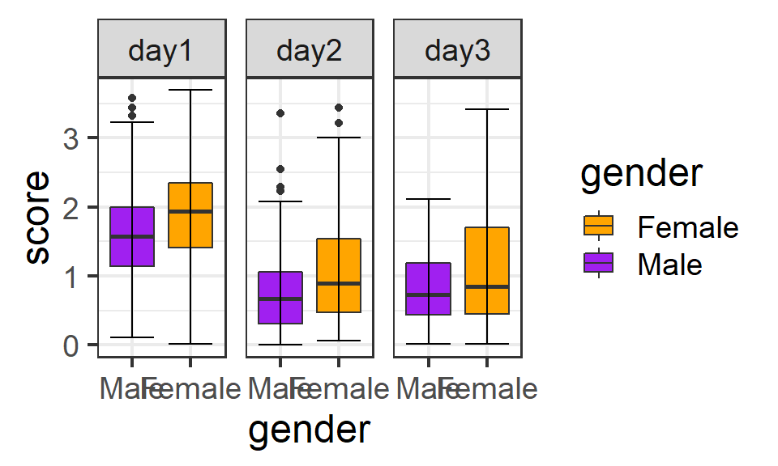

```r
{
    my.boxplot = ggplot(data = festival.data.stack, aes(gender,score, fill=gender)) + geom_boxplot() + facet_grid(~day)
    # scale_fill_manual要配合fill=gender来使用
    my.boxplot = my.boxplot + scale_fill_manual(values=c('orange', 'purple')) + stat_boxplot(geom='errorbar')
    # 改变x-轴标签顺序
    my.boxplot = my.boxplot + scale_x_discrete(limits=c('Male', 'Female'))
    my.boxplot
}
```

### 小提琴图

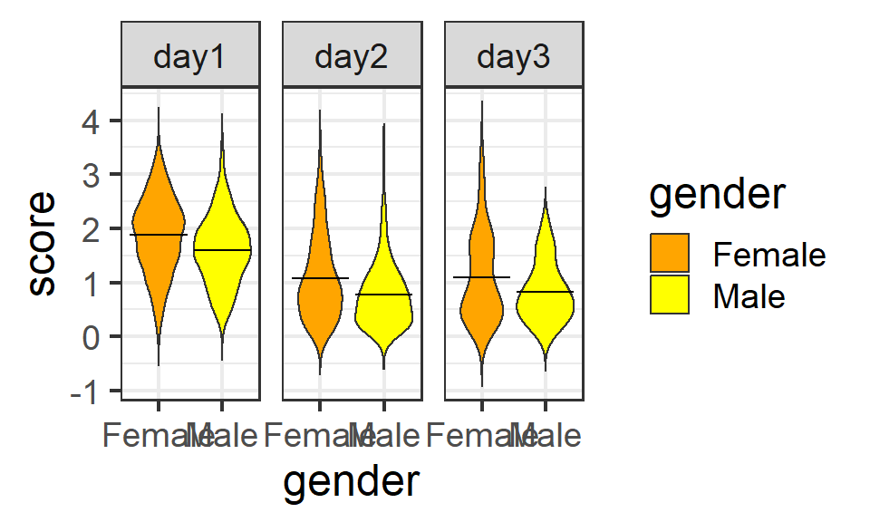

```r
{
    my.violinplot = ggplot(festival.data.stack, aes(gender, score, fill=gender)) +
                    geom_violin(trim=FALSE) +
                    facet_grid(~day) +
                    stat_summary(fun.data = festival.data.stack, geom = "errorbar", width = .5) +
                    stat_summary(geom = "errorbar", fun.y = mean, aes(ymin = ..y.., ymax = ..y..)) +
                    scale_fill_manual(values=c('orange', 'yellow'))
    my.violinplot
}
```

### 条形图

```r
score.sem = data.frame(gender=rep(c('Female', 'Male'), each=3),
                       day=rep(c('day1', 'day2', 'day3'), 2),
                       mean=c(1.88, 1.08, 1.10, 1.60, 0.77, 0.83),
                       sem=c(0.032, 0.061, 0.099, 0.036, 0.058, 0.073))
head(score.sem)
```

```
## # A tibble: 6 x 4
##   gender day    mean   sem
## * <fct>  <fct> <dbl> <dbl>
## 1 Female day1   1.88 0.032
## 2 Female day2   1.08 0.061
## 3 Female day3   1.1  0.099
## 4 Male   day1   1.6  0.036
## 5 Male   day2   0.77 0.058
## 6 Male   day3   0.83 0.073
```

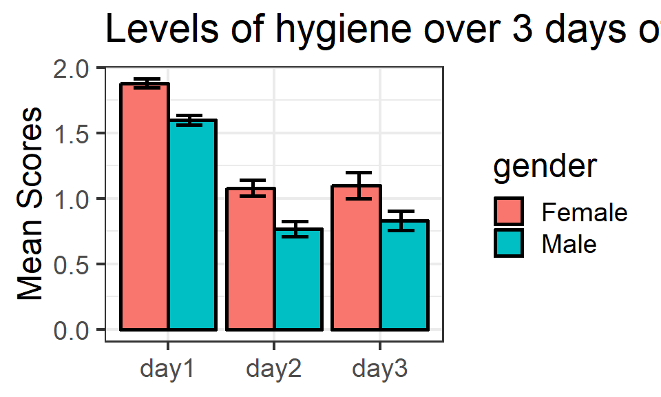

```r
{
    # geom_errorbar要和stat='identity'一起使用,不然无法知道该进行何类统计
    my.barplot = ggplot(data = score.sem, aes(day, mean, fill=gender)) +
                 geom_bar(stat='identity', position='dodge', color='black', size=1) +
                 geom_errorbar(aes(ymin=mean-sem, ymax=mean+sem), position=position_dodge(width=0.8), size=1, width=.5) +
                 ylab('Mean Scores') + ggtitle('Levels of hygiene over 3 days of concert') +
                # 去掉x轴标签
                 theme(axis.title.x=element_blank()) +
                 theme(plot.title=element_text(vjust=+2))
    my.barplot
}
```

### 堆积条形图/百分比堆积图

```r
Changing = read.csv('Changing.csv')
head(Changing)
```

```
## # A tibble: 6 x 3
##   Type.of.Behaviour Sample.Size Stage.of.Change
## * <fct>                   <int> <fct>
## 1 Smoking cessation         108 Precontemplation
## 2 Smoking cessation         187 Contemplation
## 3 Smoking cessation           0 Preparation
## 4 Smoking cessation         134 Action
## 5 Smoking cessation         247 Maintenance
## 6 Quitting cocaine            8 Precontemplation
```

[figure not shown]

```r
{
    my.stackbarchart = ggplot(Changing, aes(Type.of.Behaviour, Sample.Size, fill=Stage.of.Change)) +
                geom_bar(stat='identity') +
                coord_flip() # 水平和垂直堆积变换

    # 由于各个堆积图内部的排序都不一致，把stage.of.change改为因子就可以
    Changing$Stage.of.Change = factor(Changing$Stage.of.Change,
                                      levels=c("Precontemplation", "Contemplation", "Preparation", "Action",
                                                                         "Maintenance"))
    my.stackbarchart = ggplot(Changing, aes(Type.of.Behaviour, Sample.Size, fill=factor(Stage.of.Change))) +
        geom_bar(stat='identity') +
        coord_flip() +
        scale_fill_brewer(palette=3) +
        labs(title='Stages of Each of the 12 Problems Behaviours',
             y='Type of Behaviour',
             x='Sample Size',
             fill='Stage of Change')
    my.stackbarchart

    # 画成百分比堆积图
    contingency.table = xtabs(Sample.Size~Type.of.Behaviour+Stage.of.Change, Changing)
    contingency.tab100 = prop.table(contingency.table, 1)
    contingency.tab100 = contingency.tab100*100
    contingency.percent = as.data.frame(contingency.tab100)
    contingency.percent$Stage.of.Change = factor(contingency.percent$Stage.of.Change,
                                                 levels=c("Precontemplation", "Contemplation", "Preparation", "Action",
                                                          "Maintenance"))
    my.stackbarchart.percent = ggplot(contingency.percent, aes(Type.of.Behaviour, Freq, fill=factor(Stage.of.Change))) +
        geom_bar(stat='identity') +
        coord_flip() +
        scale_fill_brewer(palette='RdYlGn') +
        labs(title='Freq of Each of the 12 Problems Behaviours',
             y='Freq',
             x='Type of Behaviour',
             fill='Stage of Change')

    my.stackbarchart.percent
}
```

### 线图

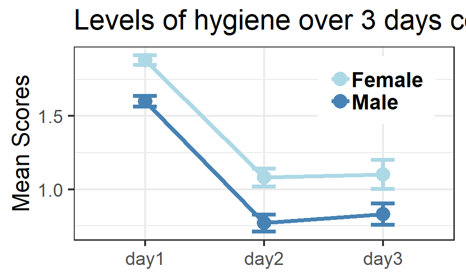

```r
{
    my.linegraph = ggplot(data = score.sem, aes(day, mean, group=gender, color=gender)) +
                    geom_line(size=1.5) + geom_point() +
                    geom_errorbar(aes(ymin=mean-sem, ymax=mean+sem))

    my.linegraph = ggplot(data = score.sem, aes(day, mean, group=gender, color=gender)) +
        geom_line(size=1.5) + geom_point(size=5) +
        geom_errorbar(aes(ymin=mean-sem, ymax=mean+sem), width=.2, size=1.5) +
        ylab('Mean Scores') + ggtitle('Levels of hygiene over 3 days concert') +
        theme(axis.title.x = element_blank()) +
        scale_color_manual(values=c('lightblue', 'steelblue')) +
        theme(legend.justification = c(1,1), legend.position = c(0.95,0.95)) +
        theme(legend.text = element_text(size=16, face='bold')) +
        theme(legend.title=element_blank(), plot.title=element_text(vjust=+2))
    my.linegraph
}
```

## 参考

- 《R 数据科学》
- [ggplot reference](https://ggplot2.tidyverse.org/reference/)
- 《ggplot2：数据分析与图形艺术》
- Tutorials from Anne Segonds-Pichon in Babraham Bioinformatics (links not found)